# Deep Evolution: Core Microbiome Parameter Exploration

## Preparation

This notebook shows the outcome of some of the parameter testing for the core microbiome analysis of the deep evolution project.

Load Libraries

```r
library(tidyverse)
library(ggalluvial)
library(scales)
library(ggbeeswarm)
library(data.table)
library(patchwork)
```

Load data

```r
data_raw <- Sys.glob("../04-analysis/screening/presenceabsence_intersection.backup") %>%
  list.files("08a-*", full.names = T) %>%
  enframe(name = NULL, value = "file_name") %>%
  mutate(file_contents = map(file_name, ~suppressMessages(read_tsv(.x))),
         Database = map(file_name, ~str_split(.x, "_") %>% unlist() %>% tail(8) %>% head(n = 1) %>% as.character) %>% unlist,
         Min_Supp = map(file_name, ~str_split(.x, "_") %>% unlist() %>% tail(7) %>% head(n = 1)) %>% unlist,
         Inds_Frac = map(file_name, ~str_split(.x, "_") %>% unlist() %>% tail(6) %>% head(n = 1) %>% str_replace("fracinds", "") %>% as.numeric) %>% unlist,
         Pops_Frac = map(file_name, ~str_split(.x, "_") %>% unlist() %>% tail(5) %>% head(n = 1) %>% str_replace("fracpops", "") %>% as.numeric) %>% unlist,
         Single_Pops_Dropped = map(file_name, ~str_split(.x, "_") %>% unlist() %>% tail(4) %>% head(n = 1) %>% str_replace("singleindpopsdropped", "") %>% as.logical) %>% unlist,
         Grouping = map(file_name, ~str_split(.x, "_") %>% unlist() %>% tail(3) %>% head(n = 1)) %>% unlist,
         Level = map(file_name, ~str_split(.x, "_") %>% unlist() %>% tail(2) %>% head(n = 1)) %>% unlist,
         Date = map(file_name, ~str_split(.x, "_") %>% unlist() %>% tail(1) %>% head(n = 1)) %>% unlist %>% str_replace(".tsv", "")) %>%
  select(-file_name) %>%
  filter(Date == "20190902",
         !Min_Supp %in% c(0.08, 0.09) ) %>%
  unnest()
```

```
`cols` is now required when using unnest().
Please use `cols = c(file_contents)`
```

```r
data_raw <- Sys.glob("../04-analysis/screening/presenceabsence_intersection.backup") %>%
  list.files("08b-*", full.names = T) %>%
  enframe(name = NULL, value = "file_name") %>%
  mutate(file_contents = map(file_name, ~suppressMessages(read_tsv(.x))),
         Database = map(file_name, ~str_split(.x, "_") %>% unlist() %>% tail(8) %>% head(n = 1) %>% as.character) %>% unlist,
         Min_Supp = map(file_name, ~str_split(.x, "_") %>% unlist() %>% tail(7) %>% head(n = 1)) %>% unlist,
         Inds_Frac = map(file_name, ~str_split(.x, "_") %>% unlist() %>% tail(6) %>% head(n = 1) %>% str_replace("fracinds", "") %>% as.numeric) %>% unlist,
         Pops_Frac = map(file_name, ~str_split(.x, "_") %>% unlist() %>% tail(5) %>% head(n = 1) %>% str_replace("fracpops", "") %>% as.numeric) %>% unlist,
         Single_Pops_Dropped = map(file_name, ~str_split(.x, "_") %>% unlist() %>% tail(4) %>% head(n = 1) %>% str_replace("singleindpopsdropped", "") %>% as.logical) %>% unlist,
         Grouping = map(file_name, ~str_split(.x, "_") %>% unlist() %>% tail(3) %>% head(n = 1)) %>% unlist,
         Level = map(file_name, ~str_split(.x, "_") %>% unlist() %>% tail(2) %>% head(n = 1)) %>% unlist,
         Date = map(file_name, ~str_split(.x, "_") %>% unlist() %>% tail(1) %>% head(n = 1)) %>% unlist %>% str_replace(".tsv", "")) %>%
  select(-file_name) %>%
  filter(Date == "20190902") %>%
  unnest() %>%
  bind_rows(data_raw)
```

```
`cols` is now required when using unnest().
Please use `cols = c(file_contents)`
```

## Aesthetics

Colour Combinations

```r
colours <- c(`Alouatta` = "#1f78b4",
              `Alouatta:Gorilla` = "#a6cee3",
              `Alouatta:Gorilla:Homo` = "#b15928",
              `Alouatta:Gorilla:Pan` = "#fdbf6f",
              `Alouatta:Gorilla:Pan:Homo` = "#cab2d6",
              `Alouatta:Gorilla:Pan:Homo:Control` = "#525252",
              `Alouatta:Homo` = "#ffff99",
              `Alouatta:Pan` = "#fb8072",
              `Alouatta:Pan:Homo` = "#fdb462",
              `Control` = "#252525",
              `Gorilla` = "#6a3d9a",
              `Gorilla:Pan` = "#bc80bd",
              `Gorilla:Pan:Homo` = "#b3de69",
              `Gorilla:Pan:Homo:Control` = "#969696",
              `Homo` = "#ff7f00",
              `Pan` = "#33a02c",
              `Pan:Homo` = "#fee090",
              `Pan:Homo:Control` = "#d9d9d9",
             `Control` = "lightgrey"
             )
```

## Min. Support Comparison

### All Host Combinations

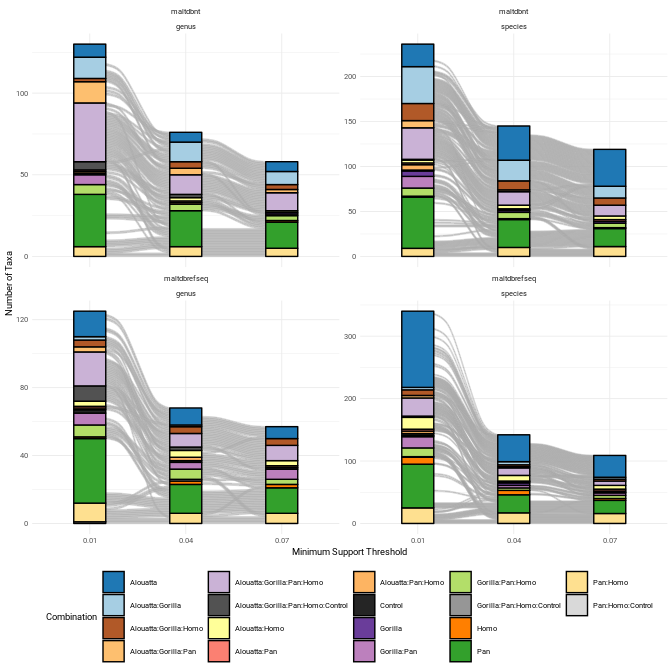

```r
data_minsup_all <- data_raw %>%
  filter(!Single_Pops_Dropped) %>%
  select(Database, Combination, Min_Supp, Taxon, Tax_Level)

ggplot(data_minsup_all,
       aes(x = Min_Supp, stratum = Combination, alluvium = Taxon,
           label = Combination)) +
  geom_flow(stat = "alluvium",
            color = "darkgray",
            lode.guidance = "zigzag", na.rm = F) +
  geom_stratum(aes(fill = Combination), na.rm = F) +
  scale_fill_manual(values = colours) +
  xlab("Minimum Support Threshold") +
  ylab("Number of Taxa") +
  theme_minimal(base_family = "Roboto", base_size = 7) +
  theme(legend.position = "bottom") +
  facet_wrap(Database ~ Tax_Level, scales = "free_y")
```

```r
NA
NA
```

We can see in most cases, the *Alouatta* and *Pan* core taxa are reduced significantly when increasing the minimum support value from 0.01 to 0.04. There is also fewer combination assignment changes when increasing 0.04 to 0.07. ]

### Monophyletic Host Combinations

To look at finer detail, we can look at the assigments to our expected phylogenetic core

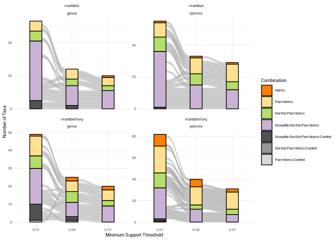

```r
data_minsup_mhc <- data_raw %>%
  filter(!Single_Pops_Dropped,
         Combination %in% c("Homo", "Pan:Homo", "Gorilla:Pan:Homo", "Alouatta:Gorilla:Pan:Homo", "Alouatta:Gorilla:Pan:Homo:Control", "Gorilla:Pan:Homo:Control", "Pan:Homo:Control")) %>%
  mutate(Combination = factor(Combination, c("Homo", "Pan:Homo", "Gorilla:Pan:Homo", "Alouatta:Gorilla:Pan:Homo", "Alouatta:Gorilla:Pan:Homo:Control", "Gorilla:Pan:Homo:Control", "Pan:Homo:Control") )) %>%
  select(Database, Tax_Level, Min_Supp, Combination, Taxon, )

plot_mhc <- ggplot(data_minsup_mhc,
       aes(x = Min_Supp, stratum = Combination, alluvium = Taxon,
           label = Combination)) +
  geom_flow(stat = "alluvium",
            color = "darkgray",
            lode.guidance = "zigzag", na.rm = F) +
  geom_stratum(aes(fill = Combination), na.rm = F) +
  scale_fill_manual(values = colours) +
  xlab("Minimum Support Threshold") +
  ylab("Number of Taxa") +
  theme_minimal(base_family = "Roboto", base_size = 7) +
  theme(legend.position = "right") +
  facet_wrap(Database ~ Tax_Level, scales = "free_y")

plot_mhc
```

```r
 ggsave(paste("99-coremicrobiome_presenceabsence_alluival_minsupportcomparison_", format(Sys.Date(), "%Y%m%d"),".pdf", sep = ""),
        plot_mhc,
        path = "../04-analysis/screening/presenceabsence_intersection.backup/",
        device = cairo_pdf,
        width = 7,
        height = 5,
        units = "in",
        dpi = 600)

  ggsave(paste("99-coremicrobiome_presenceabsence_alluival_minsupportcomparison_", format(Sys.Date(), "%Y%m%d"),".png", sep = ""),
        plot_mhc,
        path = "../04-analysis/screening/presenceabsence_intersection.backup/",
        device = "png",
        width = 7,
        height = 5,
        units = "in",
        dpi = 600)

write_tsv(data_minsup_mhc, paste("../04-analysis/screening/presenceabsence_intersection.backup/99-coremicrobiome_presenceabsence_table_minsupportcomparison_", format(Sys.Date(), "%Y%m%d"),".tsv", sep = ""))
```

We we confirm that increasing our minimum support from 0.04 to 0.07 we remove all combinations including controls, removing potential laboratory control taxa. We see about half of each category being lost to other non-monophyletic assignments when increasing 0.01 to 0.4, however again much fewer assignments changes between 0.04 and 0.07.

### Monophyletic Host Combinations 0.04 to 0.07 only.

To get a better feeling of the different types of combination assignments, we can firstly remove the 0.01 category as this is likely consisting a lot of low-abundant taxa (or tail), which in our context will be difficult to separate from noise - either from misassignments from unspecific short reads, damage, or background environmental contamination.

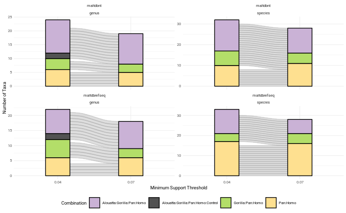

```r
data_minsup_mhcreduced <- data_raw %>%
  filter(!Single_Pops_Dropped,
         Combination %in% c("Pan:Homo", "Gorilla:Pan:Homo", "Alouatta:Gorilla:Pan:Homo", "Alouatta:Gorilla:Pan:Homo:Control"),
         Min_Supp != 0.01) %>%
  select(Database, Combination, Min_Supp, Taxon, Tax_Level)

ggplot(data_minsup_mhcreduced,
       aes(x = Min_Supp, stratum = Combination, alluvium = Taxon,
           label = Combination)) +
  geom_flow(stat = "alluvium",
            color = "darkgray",
            lode.guidance = "zigzag", na.rm = F) +
  geom_stratum(aes(fill = Combination), na.rm = F) +
  scale_fill_manual(values = colours) +
  xlab("Minimum Support Threshold") +
  ylab("Number of Taxa") +
  theme_minimal(base_family = "Roboto", base_size = 7) +
  theme(legend.position = "bottom") +
  facet_wrap(Database ~ Tax_Level, scales = "free_y")
```

Using our more confident 0.04 and 0.07 categories, we can see there are 2-3 changing of asignments to combinations outside the monophyletic expected combinations, and a few reassignments. We can check more specifically what these are as follows.

```r
data_minsup_mhcreduced %>%
  spread(Min_Supp, Combination) %>%
  filter(`0.04` != `0.07`) %>%
  arrange(Database, Tax_Level)
```

| Database | Taxon | Tax_Level | 0.04 | 0.07 |
| --- | --- | --- | --- | --- |
| maltdbnt | Mycobacterium | genus | Alouatta:Gorilla:Pan:Homo:Control | Alouatta:Gorilla:Pan:Homo |
| maltdbnt | Streptococcus | genus | Alouatta:Gorilla:Pan:Homo:Control | Alouatta:Gorilla:Pan:Homo |
| maltdbnt | Anaerolineaceae_bacterium_oral_taxon_439 | species | Gorilla:Pan:Homo | Pan:Homo |
| maltdbnt | Campylobacter_gracilis | species | Alouatta:Gorilla:Pan:Homo | Gorilla:Pan:Homo |
| maltdbnt | Olsenella_sp._oral_taxon_807 | species | Gorilla:Pan:Homo | Pan:Homo |
| maltdbnt | Tannerella_forsythia | species | Gorilla:Pan:Homo | Pan:Homo |
| maltdbrefseq | Actinomyces | genus | Alouatta:Gorilla:Pan:Homo:Control | Alouatta:Gorilla:Pan:Homo |
| maltdbrefseq | Corynebacterium | genus | Alouatta:Gorilla:Pan:Homo:Control | Alouatta:Gorilla:Pan:Homo |
| maltdbrefseq | Johnsonella | genus | Gorilla:Pan:Homo | Pan:Homo |
| maltdbrefseq | Treponema | genus | Gorilla:Pan:Homo | Pan:Homo |

[output cut: 3 more lines]

Here we can see 2 changes for nt genus, 4 for nt species, and 4 for RefSeq genus and 3 for refseq species. All taxa other than Mycobacterium are isolated from the oral cavity. Mycobacterium is a highly diverse environmental taxon. As we do not calculate core with actual abundance (other than filtering by the minimum support value), this likely is retained as core in samples as it is a combination of control and burial environment *Mycobacterium* reads, rather than being a true oral taxa. The other taxa that are reassigned from a (+control) core to host only - *Streptococus*, *Actinomyces* and *Corynebacterium* are diverse taxa that reside in many parts of the human body. It is likely these alignments are combinations of ancient oral and modern skin contamination, and are reassigned as the lower-abundant skin contamination is removed by increasing to 0.07, leaving the highly abundant oral assignments. As all other taxa are known to be isolated or specfic to the oral cavity this suggests their authenticity. Most changes to the `Pan:Homo` combination are from anaerobic bacteria (e.g. *Tannerella*, *Treponema*, *Olsenella*) - representative of the stronger signal of these taxa in *Homo* and *Pan* vs. *Gorilla* and *Alouatta* which have lower abundances of later colonisers, whereas to *Gorilla:Pan:Homo*, these are aerobic taxa typically represent early colonisers - which are more prevalent in *Gorilla*.

## Single Population

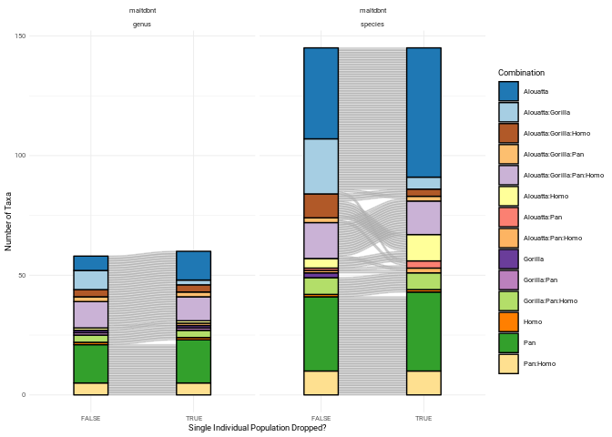

## WTF Mycobacterium?

We also note that we have *Mycobacterium* still being maintained in our nt core.

This is a bit odd as it’s a common environmental contaminant. Indeed, even at 0.04% minimum support it is actually in a core with the controls. Lets see if we can look a little closer at this. Is it also in genus in refseq?

We can check this more specifically.

Set aesthetics

to save plot for paper